# Enrichment_gnavus_Elder

2024-10-04

# Analysis enrichment

In this notebook I will show how there is an enrichment of elder individuals within a clade of R. gnavus. I load the output from anpan which has been saved as RDS files, anf from it I extract the median (from the posterior distribution) phylogenetic effect per leaf. I will use this for plotting, and to define the clade of interest.

```r
set.seed(12234)
library(tidyverse)
library(anpan)
library(ape)
library(ggtree)
library(ggtreeExtra)
library(ggnewscale)
library(lmerTest)
library(phytools)
setwd("/mnt/project/Make_Associations/Git/PhylogeneticAssociation/Analyses_revision")
Process_RDS = function(Data){
  read_rds(Data) -> Data
  Data$model_input -> Info
  Data$pglmm_fit$summary() -> Data
  print("Preparing information table")
  Data %>% filter( grepl("phylo", variable))  %>% filter(! grepl("std", variable)) %>% mutate(sample_id = factor(c("-", as.character(Info$sample_id)))) %>%
    select(sample_id, median) %>% rename(phylo_effect_median = median) -> Phylo
  left_join(Info, Phylo) %>% mutate(sample_id = as.character(sample_id)) -> Phylo
  return(Phylo)
}
Process_tree = function(Tree){
  read.tree(Tree) -> Tree
  if (class(Tree) ==  "multiPhylo"){ Tree = Tree[[1]] }
  Tree = midpoint.root(Tree)
  #2. Rename labels tree
  print("Processing tree")
  Tree$tip.label %>% sapply(. , Clean_names) -> New_names
  Tree$tip.label = as.vector(New_names)
  if ( length(Tree$tip.label) < 100 ) { print("Tree is too small") ; q() }
  return(Tree)

}
Clean_names =  function(Name){
  'Samples from 500FG FSK need everything after _ to be removed. If _metaphlan4 is attached at the end of the name, remove'
  if ( grepl("HV", Name)) {
    Name = str_split(Name, "_")[[1]][1]
  }
  Name = str_replace(Name, "_metaphlan4", "")
  return(Name)
}
Remove_repeated2 = function(Metadata){
  'Check which samples are repeated (either duplicates or longitudinally) and only picks one from the repeated'
  set.seed(89777)
  Metadata %>% group_by(subject_id) %>% summarise(N = n()) %>% arrange(desc(N)) %>% filter(N > 1 ) -> Replicates
  remove = tibble()
  for (i in Replicates$subject_id){
    Metadata %>% filter(subject_id == i) -> Filtered ; Samples = Filtered$ID_anal
    Keep = sample(Samples, 1)
    remove = c(remove, Samples[!Samples==Keep] )
  }
  remove = unlist(remove)
  Metadata %>% filter(! ID_anal %in% remove) -> Metadata
  return(Metadata)
}
```

We read the phenotypic information from all samples, and the phylogenetic results in European, Asian, and only XuQ_2021, of associating R. gnavus (t__SGB4584) and age using anpan.

```
## [1] "Preparing information table"
```

```
## [1] "Preparing information table"
```

```
## [1] "Preparing information table"
```

```
## [1] "Processing tree"
```

We will use this function to define the ‘elder clade’. Basically, using the data from XuQ, get the clade that descent in the individuals with high median phylogenetic effect.

```r
GetNodeAncesterClade = function(Tree, df =Age_xu ){
  #Get the node that descendents in the individuals with higher phylogenetic effect
  Names = filter(df, phylo_effect_median>9.5)$sample_id
  match( Names , Tree$tip.label) -> CHECK
  common_ancestor <- getMRCA(Tree, CHECK)
  return(common_ancestor)
}
```

## Plot tree

This function will plot a tree with the results from anpan on the leaves, and highlighting the clade of interest

```r
Plot_age_effect = function(Tree, Phenotypes, Phylo_age){
  left_join(Phylo_age, Phenotypes,by="sample_id") -> Phylo_age
  #Only keep branches of the subjects of interest
  keep.tip(Tree, Phylo_age$sample_id) -> Tree
  print(Tree)

  Phylo_age %>% mutate(`Age>=80` = ifelse(Age>=80, T, F), Septuagenarian = ifelse(Age>=70, T, F), Nonagenarian =   ifelse(Age>=90, T, F))  -> Phylo_age

  Node = GetNodeAncesterClade(Tree)
  print(paste0("MCA:",Node))
  #Plot tree
  ggtree(Tree, layout="fan", open.angle=15, size=0.1) %<+% Phylo_age  -> p
p + geom_fruit( geom="geom_tile", mapping = aes(fill=phylo_effect_median), width=0.03,offset=0.1) + scale_fill_viridis_c(option = "magma") +
  new_scale_fill() + geom_fruit( geom="geom_tile", mapping = aes(fill=`Age>=80`), width=0.03,offset=0.05) + scale_fill_manual(values=c("TRUE"= "#E31A1C", "FALSE"="white") )  +
  new_scale_fill() + geom_fruit( geom="geom_tile", mapping = aes(fill=Age), width=0.03,offset=0.05 )  + scale_fill_viridis_c(option = "viridis") + geom_balance(node=Node  , fill="grey", color=NA, alpha=0.3) -> Tree_elderClade

  if ("Continent" %in% colnames(Phylo_age) & length(unique(Phylo_age$Continent)) > 1   ){
    Tree_elderClade + new_scale_fill() + geom_fruit( geom="geom_tile", mapping = aes(fill=Continent), width=0.03,offset=0.05 ) + scale_fill_manual(values=c("Europe" = "#1f77b4", "Asia" = "#E31A1C"))  -> Tree_elderClade
  }

  return(Tree_elderClade)

}
```

```r
Plot_age_effect(Tree_gnavus_all, Phenos_merge, Age_xu) -> Plot
```

```
##
## Phylogenetic tree with 96 tips and 95 internal nodes.
##
## Tip labels:
##   QinN_longevity_Sample045, QinN_longevity_Sample054, QinN_longevity_Sample082, QinN_longevity_Sample176, QinN_longevity_Sample169, QinN_longevity_Sample063, ...
##
## Rooted; includes branch lengths.
## [1] "MCA:163"
```

Plot results from association in all Asian samples

```r
Plot_age_effect(Tree_gnavus_all, Phenos_merge, Age_Asia)-> Plot
```

```
##
## Phylogenetic tree with 969 tips and 968 internal nodes.
##
## Tip labels:
##   SAMEA104142463, LD-62, AS40raw, SAMD00114845, SAMEA104142356, CON-046, ...
##
## Rooted; includes branch lengths.
## [1] "MCA:1874"
```

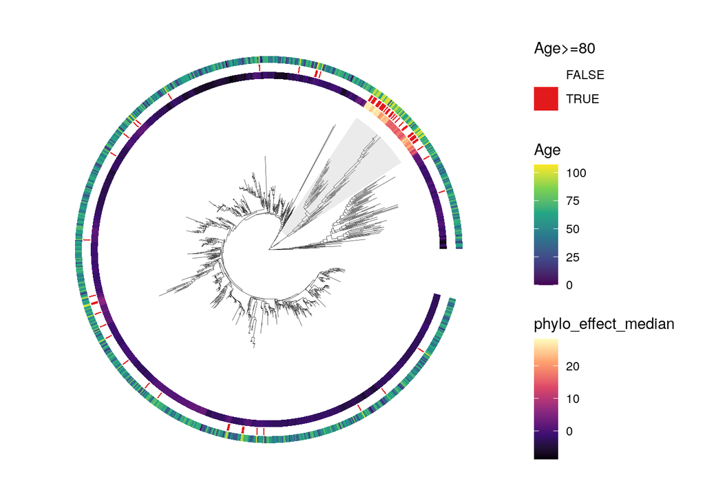

```r
ggsave("/mnt/project/Make_Associations/Git/PhylogeneticAssociation/Analyses_revision/Figures/Rgnavus_elderclade_Asia.pdf",Plot)
Plot
```

```r
rbind ( Age_europe, Age_Asia) -> Combined_info
Plot_age_effect(Tree_gnavus_all, Phenos_merge, Combined_info) -> Plot
```

```
##
## Phylogenetic tree with 2158 tips and 2157 internal nodes.
##
## Tip labels:
##   SAMEA104142463, LD-62, G78574, AS40raw, SAMD00114845, SAMEA104142356, ...
##
## Rooted; includes branch lengths.
## [1] "MCA:3982"
```

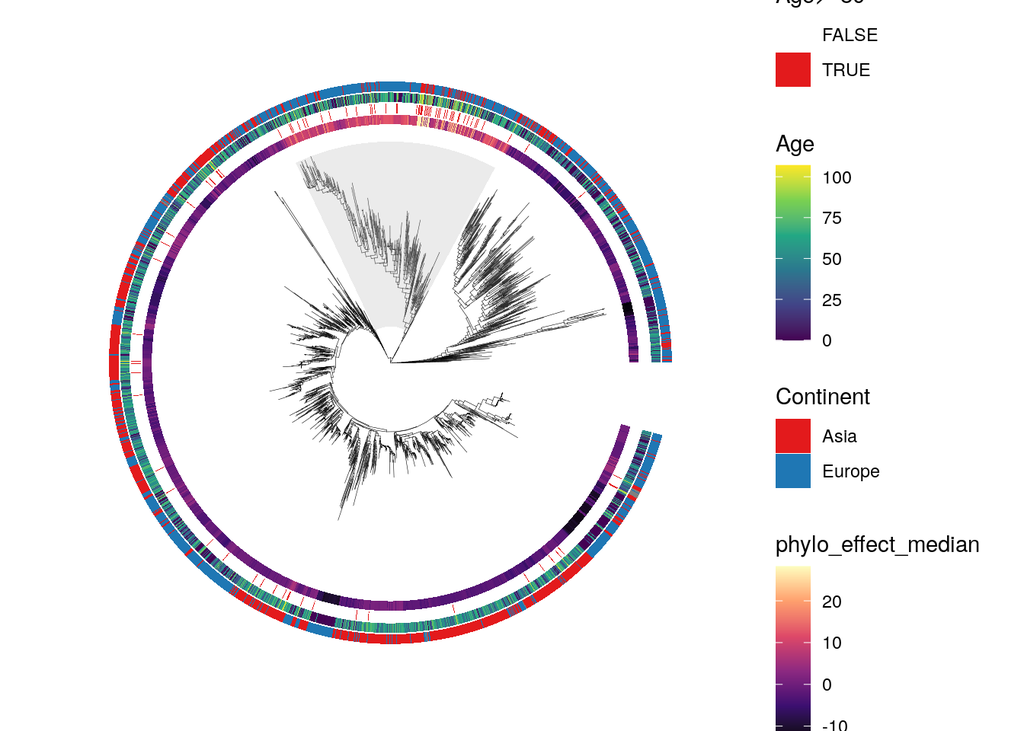

```r
ggsave("/mnt/project/Make_Associations/Git/PhylogeneticAssociation/Analyses_revision/Figures/Rgnavus_elderclade_AsiaEurope.pdf",Plot)
Plot
```

## Enrichment clade

Now, I will show that this clade is enriched in elder individuals, in XuQ2021, Asian samples, and European samples. I will use this function to define which samples fall within the Elder clade, and run enrichment tests for the presence of individuals >70, >80, or >90 years old, and continuous logistic regression test to show that the odds of having a strain in this clade increase with age (while accounting for study specific effects).

```r
Enrichment_elder = function(Tree, Phenotypes, Phylo_age, Is_Eur=F ){
  #Prepare data
  left_join(Phylo_age, Phenotypes,by="sample_id") -> Phylo_age
  keep.tip(Tree, Phylo_age$sample_id) -> Tree
  Phylo_age %>% mutate(Octagenarian = ifelse(Age>=80, T, F), Septuagenarian = ifelse(Age>=70, T, F), Nonagenarian = ifelse(Age>=90, T, F))  -> Phylo_age
  #Get assignment to clade
  Node = GetNodeAncesterClade(Tree)
  Tree$tip.label[getDescendants(Tree, Node)] -> Aging_clade
  Phylo_age %>% mutate(Elder_clade = ifelse(sample_id %in% Aging_clade, T, F ) ) -> Phylo_age
  if (Is_Eur==T){
    Phylo_age %>% filter(Continent == "Europe") -> Phylo_age
  }
  #Run enrichment
  List_enrichment = list()
  for ( Age_group in c("Septuagenarian", "Octagenarian", "Nonagenarian") ){
    Phylo_age[[Age_group]] =  as.factor(Phylo_age[[Age_group]] )
    Phylo_age[["Elder_clade"]] =  as.factor(Phylo_age[["Elder_clade"]] )

    #If not enough samples, skip
    if ( length(levels(Phylo_age[[Age_group]]) ) == 1  ){
      print(paste0("Not enough ", Age_group, " samples (0): Skipping" ))
      next()
    }

    contingency_table <- table(Phylo_age[[Age_group]], Phylo_age$Elder_clade)
    colnames(contingency_table) = paste0( paste0(Age_group,"_") ,levels(Phylo_age[[Age_group]]) )
    rownames(contingency_table) = paste0("Clade_" ,levels(Phylo_age$Elder_clade) )

    fisher_result <- fisher.test(contingency_table)

    List_enrichment[[Age_group]] = list( "Contingency_table" =  contingency_table, P_fisher = fisher_result$p.value)
  }
  print("Fisher test enrichment results: ")
  print(List_enrichment)
  #Run a logistic regression (age as a continuous variable)
  #if more than one study, control for study as a random effect
  N_studies = Phylo_age$study_name %>% unique() %>% length()
  print(paste0("Number of studies in dataset:", N_studies ) )
  if (N_studies == 1 ){
    glm( as.factor(Elder_clade) ~ Age,Phylo_age, family=binomial ) %>% summary() -> Model
  } else {
    glmer( as.factor(Elder_clade) ~ Age + (1|study_name), Phylo_age, family=binomial ) %>% summary() -> Model
  }
  print("Logistic regression results: ")
  print( Model$coefficients )
  return(Phylo_age)
}
```

Run enrichment in XuQ

```r
Age_xu2 = Enrichment_elder(Tree_gnavus_all, Phenos_merge, Age_xu)
```

```
## [1] "Fisher test enrichment results: "
## $Septuagenarian
## $Septuagenarian$Contingency_table
##
##               Septuagenarian_FALSE Septuagenarian_TRUE
##   Clade_FALSE                   32                   1
##   Clade_TRUE                    34                  29
##
## $Septuagenarian$P_fisher
## [1] 5.114342e-06
##
##
## $Octagenarian
## $Octagenarian$Contingency_table
##
##               Octagenarian_FALSE Octagenarian_TRUE
##   Clade_FALSE                 47                 1
##   Clade_TRUE                  19                29
##
## $Octagenarian$P_fisher
## [1] 1.634568e-10
##
##
## $Nonagenarian
## $Nonagenarian$Contingency_table
##
##               Nonagenarian_FALSE Nonagenarian_TRUE
##   Clade_FALSE                 48                 1
##   Clade_TRUE                  18                29
##
## $Nonagenarian$P_fisher
## [1] 3.573867e-11
##
##
## [1] "Number of studies in dataset:1"
## [1] "Logistic regression results: "
##                Estimate Std. Error   z value     Pr(>|z|)
## (Intercept) -13.7011488 3.31408584 -4.134217 3.561674e-05
## Age           0.1460685 0.03508973  4.162715 3.144860e-05
```

Run enrichment in Asian tree

```r
Age_Asia2 = Enrichment_elder(Tree_gnavus_all, Phenos_merge, Age_Asia)
```

```
## [1] "Fisher test enrichment results: "
## $Septuagenarian
## $Septuagenarian$Contingency_table
##
##               Septuagenarian_FALSE Septuagenarian_TRUE
##   Clade_FALSE                  749                  21
##   Clade_TRUE                   155                  44
##
## $Septuagenarian$P_fisher
## [1] 1.207956e-17
##
##
## $Octagenarian
## $Octagenarian$Contingency_table
##
##               Octagenarian_FALSE Octagenarian_TRUE
##   Clade_FALSE                873                34
##   Clade_TRUE                  31                31
##
## $Octagenarian$P_fisher
## [1] 1.819227e-23
##
##
## $Nonagenarian
## $Nonagenarian$Contingency_table
##
##               Nonagenarian_FALSE Nonagenarian_TRUE
##   Clade_FALSE                885                36
##   Clade_TRUE                  19                29
##
## $Nonagenarian$P_fisher
## [1] 4.72419e-25
##
##
## [1] "Number of studies in dataset:15"
## [1] "Logistic regression results: "
##                Estimate Std. Error   z value     Pr(>|z|)
## (Intercept) -8.85128513 1.00291983 -8.825516 1.089561e-18
## Age          0.08958848 0.01332111  6.725303 1.752270e-11
```

Run enrichment in European samples. Here, to define the clade, we need to keep the samples form XuQ in the tree, use them to get the MRCA and then remove them.

```r
rbind ( Age_europe, Age_Asia) -> Combined_info
Age_europe2 = Enrichment_elder(Tree_gnavus_all, Phenos_merge, Combined_info, Is_Eur=T)
```

```
## [1] "Not enough Nonagenarian samples (0): Skipping"
## [1] "Fisher test enrichment results: "
## $Septuagenarian
## $Septuagenarian$Contingency_table
##
##               Septuagenarian_FALSE Septuagenarian_TRUE
##   Clade_FALSE                  847                 224
##   Clade_TRUE                    55                  50
##
## $Septuagenarian$P_fisher
## [1] 9.377284e-09
##
##
## $Octagenarian
## $Octagenarian$Contingency_table
##
##               Octagenarian_FALSE Octagenarian_TRUE
##   Clade_FALSE                893               262
##   Clade_TRUE                   9                12
##
## $Octagenarian$P_fisher
## [1] 0.0007729074
##
##
## [1] "Number of studies in dataset:36"
## [1] "Logistic regression results: "
##                Estimate  Std. Error   z value     Pr(>|z|)
## (Intercept) -2.61475587 0.292635877 -8.935186 4.064953e-19
## Age          0.03065635 0.005102816  6.007732 1.881363e-09
```

Test after removal of <18 yo

```r
Age_europe2 = Enrichment_elder(Tree_gnavus_all, Phenos_merge, Combined_info %>% filter(Age>=18), Is_Eur=T)
```

```
## [1] "Not enough Nonagenarian samples (0): Skipping"
## [1] "Fisher test enrichment results: "
## $Septuagenarian
## $Septuagenarian$Contingency_table
##
##               Septuagenarian_FALSE Septuagenarian_TRUE
##   Clade_FALSE                  462                 152
##   Clade_TRUE                    55                  50
##
## $Septuagenarian$P_fisher
## [1] 3.685992e-06
##
##
## $Octagenarian
## $Octagenarian$Contingency_table
##
##               Octagenarian_FALSE Octagenarian_TRUE
##   Clade_FALSE                508               190
##   Clade_TRUE                   9                12
##
## $Octagenarian$P_fisher
## [1] 0.005213041
##
##
## [1] "Number of studies in dataset:31"
## [1] "Logistic regression results: "
##                Estimate  Std. Error   z value     Pr(>|z|)
## (Intercept) -3.65274981 0.453245256 -8.059102 7.685687e-16
## Age          0.04686973 0.007200027  6.509660 7.532090e-11
```

```r
Combined_info2 = Enrichment_elder(Tree_gnavus_all, Phenos_merge, Combined_info %>% filter(Age>=18), Is_Eur=F)
```

```
## [1] "Fisher test enrichment results: "
## $Septuagenarian
## $Septuagenarian$Contingency_table
##
##               Septuagenarian_FALSE Septuagenarian_TRUE
##   Clade_FALSE                 1207                 173
##   Clade_TRUE                   210                  94
##
## $Septuagenarian$P_fisher
## [1] 1.487538e-13
##
##
## $Octagenarian
## $Octagenarian$Contingency_table
##
##               Octagenarian_FALSE Octagenarian_TRUE
##   Clade_FALSE               1377               224
##   Clade_TRUE                  40                43
##
## $Octagenarian$P_fisher
## [1] 4.763143e-15
##
##
## $Nonagenarian
## $Nonagenarian$Contingency_table
##
##               Nonagenarian_FALSE Nonagenarian_TRUE
##   Clade_FALSE               1398               238
##   Clade_TRUE                  19                29
##
## $Nonagenarian$P_fisher
## [1] 1.115568e-12
##
##
## [1] "Number of studies in dataset:45"
## [1] "Logistic regression results: "
##                Estimate  Std. Error    z value     Pr(>|z|)
## (Intercept) -5.20164173 0.461238009 -11.277565 1.693688e-29
## Age          0.05926357 0.006470704   9.158753 5.250069e-20
```

## Confounding

Finally, repeat enrichment for XuQ controlling for other possible confounders For that, get all metatadata available for the cohort : https://github.com/waldronlab/curatedMetagenomicDataCuration/tree/master/inst/curated/XuQ_2021

```r
read_tsv("../../../Phenotypes/Specific/XuQ_meta.tsv") -> Phenos_XuQ
left_join(Age_xu2,Phenos_XuQ, by=c("other_id" = "sample_id") ) -> Xu_confunding

#Controlling for family, disease, gender, BMI and sequencing depth
Xu_confunding %>% select(Elder_clade, Age, gender, BMI, number_reads, study_condition, family ) %>% drop_na() -> ToTest
#without disease
glmer( as.factor(Elder_clade) ~ Age + gender + BMI + scale(number_reads)  + (1|family), ToTest, family=binomial ) %>% summary()
```

```
## boundary (singular) fit: see help('isSingular')
```

```
## Generalized linear mixed model fit by maximum likelihood (Laplace
##   Approximation) [glmerMod]
##  Family: binomial  ( logit )
## Formula: as.factor(Elder_clade) ~ Age + gender + BMI + scale(number_reads) +
##     (1 | family)
##    Data: ToTest
##
##      AIC      BIC   logLik deviance df.resid
##     83.0     98.4    -35.5     71.0       90
##
## Scaled residuals:
##     Min      1Q  Median      3Q     Max
## -2.6187 -0.2287 -0.1152  0.5628  8.0740
##
## Random effects:
##  Groups Name        Variance  Std.Dev.
##  family (Intercept) 9.351e-14 3.058e-07
## Number of obs: 96, groups:  family, 71
##
## Fixed effects:
##                      Estimate Std. Error z value Pr(>|z|)
## (Intercept)         -11.63214    4.55068  -2.556 0.010584 *
## Age                   0.13921    0.04099   3.397 0.000682 ***
## gendermale           -0.08192    0.85669  -0.096 0.923821
## BMI                  -0.06439    0.07917  -0.813 0.416048
## scale(number_reads)  -0.27897    0.30629  -0.911 0.362401
## ---
## Signif. codes:  0 '***' 0.001 '**' 0.01 '*' 0.05 '.' 0.1 ' ' 1
##
## Correlation of Fixed Effects:
##             (Intr) Age    gndrml BMI
## Age         -0.924
## gendermale  -0.462  0.494
## BMI         -0.512  0.152  0.016
## scl(nmbr_r)  0.044  0.002  0.165 -0.140
## optimizer (Nelder_Mead) convergence code: 0 (OK)
## boundary (singular) fit: see help('isSingular')
```

```r
#with diease (disease increases with age, thus, colinear)
lm(Age ~ study_condition, ToTest) %>% summary() #colinearity of T2D
```

```
##
## Call:
## lm(formula = Age ~ study_condition, data = ToTest)
##
## Residuals:
##     Min      1Q  Median      3Q     Max
## -29.321 -14.571   7.417  12.866  19.679
##
## Coefficients:
##                             Estimate Std. Error t value Pr(>|t|)
## (Intercept)                   85.321      1.967  43.383  < 2e-16 ***
## study_conditionhypertension   -4.750      3.406  -1.394 0.166511
## study_conditionT2D           -17.738      4.682  -3.789 0.000268 ***
## ---
## Signif. codes:  0 '***' 0.001 '**' 0.01 '*' 0.05 '.' 0.1 ' ' 1
##
## Residual standard error: 14.72 on 93 degrees of freedom
## Multiple R-squared:  0.1357, Adjusted R-squared:  0.1171
## F-statistic: 7.298 on 2 and 93 DF,  p-value: 0.001138
```

```r
glmer( as.factor(Elder_clade) ~ Age + gender + BMI + scale(number_reads) + study_condition  + (1|family), ToTest, family=binomial ) %>% summary()
```

```
## Generalized linear mixed model fit by maximum likelihood (Laplace
##   Approximation) [glmerMod]
##  Family: binomial  ( logit )
## Formula: as.factor(Elder_clade) ~ Age + gender + BMI + scale(number_reads) +
##     study_condition + (1 | family)
##    Data: ToTest
##
##      AIC      BIC   logLik deviance df.resid
##     85.5    106.0    -34.8     69.5       88
##
## Scaled residuals:
##     Min      1Q  Median      3Q     Max
## -2.3419 -0.2171 -0.1022  0.5765  5.7848
##
## Random effects:
##  Groups Name        Variance Std.Dev.
##  family (Intercept) 0.1007   0.3173
## Number of obs: 96, groups:  family, 71
##
## Fixed effects:
##                               Estimate Std. Error z value Pr(>|z|)
## (Intercept)                 -1.120e+01  4.658e+00  -2.405  0.01615 *
## Age                          1.368e-01  4.339e-02   3.153  0.00162 **
## gendermale                  -1.900e-02  8.814e-01  -0.022  0.98280
## BMI                         -8.028e-02  8.579e-02  -0.936  0.34942
## scale(number_reads)         -2.968e-01  3.138e-01  -0.946  0.34427
## study_conditionhypertension  5.719e-01  6.993e-01   0.818  0.41349
## study_conditionT2D          -2.300e+01  1.706e+05   0.000  0.99989
## ---
## Signif. codes:  0 '***' 0.001 '**' 0.01 '*' 0.05 '.' 0.1 ' ' 1
##
## Correlation of Fixed Effects:
##             (Intr) Age    gndrml BMI    scl(_) stdy_c
## Age         -0.918
## gendermale  -0.465  0.499
## BMI         -0.412  0.028 -0.034
## scl(nmbr_r)  0.049  0.011  0.154 -0.165
## stdy_cndtnh -0.122  0.220  0.086 -0.299  0.008
## stdy_cndT2D  0.000  0.000  0.000  0.000  0.000  0.000
## optimizer (Nelder_Mead) convergence code: 0 (OK)
## unable to evaluate scaled gradient
## Model failed to converge: degenerate  Hessian with 1 negative eigenvalues
```

Overall we still find the effect. What about in European population, is this confounded for instance, by BMI/Sex/number of reads?

```r
Phenos %>% select(ID_anal, BMI, Sex,number_reads) %>% rename(sample_id = ID_anal) -> Phenos_merge_confounding
Age_europe2 %>% left_join(Phenos_merge_confounding) %>% distinct(sample_id, .keep_all = T) -> ToTest_Europe
ToTest_Europe %>% select(Elder_clade, Age, Sex, BMI, number_reads, study_name) %>% drop_na() -> ToTest_Europe2
ToTest_Europe2 %>% group_by(Elder_clade) %>% summarise(n()) %>% print()
```

```
## # A tibble: 2 × 2
##   Elder_clade `n()`
##   <fct>       <int>
## 1 FALSE         310
## 2 TRUE           90
```

```r
ToTest_Europe2 %>% glmer( as.factor(Elder_clade) ~ Age + Sex + BMI + scale(number_reads) + (1|study_name), ., family=binomial ) %>% summary()
```

```
## Generalized linear mixed model fit by maximum likelihood (Laplace
##   Approximation) [glmerMod]
##  Family: binomial  ( logit )
## Formula: as.factor(Elder_clade) ~ Age + Sex + BMI + scale(number_reads) +
##     (1 | study_name)
##    Data: .
##
##      AIC      BIC   logLik deviance df.resid
##    413.0    437.0   -200.5    401.0      394
##
## Scaled residuals:
##     Min      1Q  Median      3Q     Max
## -1.1469 -0.5675 -0.4172 -0.2884  3.6808
##
## Random effects:
##  Groups     Name        Variance Std.Dev.
##  study_name (Intercept) 0.1236   0.3516
## Number of obs: 400, groups:  study_name, 18
##
## Fixed effects:
##                      Estimate Std. Error z value Pr(>|z|)
## (Intercept)         -1.692937   0.782587  -2.163   0.0305 *
## Age                  0.034233   0.008613   3.975 7.05e-05 ***
## Sex                  0.176632   0.272131   0.649   0.5163
## BMI                 -0.056348   0.026493  -2.127   0.0334 *
## scale(number_reads) -0.052322   0.138061  -0.379   0.7047
## ---
## Signif. codes:  0 '***' 0.001 '**' 0.01 '*' 0.05 '.' 0.1 ' ' 1
##
## Correlation of Fixed Effects:
##             (Intr) Age    Sex    BMI
## Age         -0.374
## Sex         -0.262 -0.090
## BMI         -0.758 -0.247  0.110
## scl(nmbr_r) -0.104  0.043 -0.078  0.113
```

Check urbanicity in the DMP, where urbanicity index is available First check that we replciate signal in GacesaR_2022 (where we have urbanicity information)

```r
Age_europe2 %>% filter(study_name == "DAG3") %>%  group_by(Elder_clade) %>% summarise(n())
```

```
## # A tibble: 2 × 2
##   Elder_clade `n()`
##   <fct>       <int>
## 1 FALSE           5
## 2 TRUE           43
```

```r
Age_europe2 %>% filter(study_name == "DAG3") %>% glm( as.factor(Elder_clade) ~ Age, ., family=binomial  ) %>% summary()
```

```
##
## Call:
## glm(formula = as.factor(Elder_clade) ~ Age, family = binomial,
##     data = .)
##
## Coefficients:
##             Estimate Std. Error z value Pr(>|z|)
## (Intercept) -5.50683    3.29293  -1.672   0.0945 .
## Age          0.13693    0.06218   2.202   0.0277 *
## ---
## Signif. codes:  0 '***' 0.001 '**' 0.01 '*' 0.05 '.' 0.1 ' ' 1
##
## (Dispersion parameter for binomial family taken to be 1)
##
##     Null deviance: 32.078  on 47  degrees of freedom
## Residual deviance: 25.023  on 46  degrees of freedom
## AIC: 29.023
##
## Number of Fisher Scoring iterations: 6
```

Check urbanicity info

```r
#Test including urbanicity
Age_europe2 %>%  filter(study_name == "DAG3") %>% left_join(select(Phenos, ID_anal, Urbanicity), by=c('sample_id' = "ID_anal")  ) -> Test_urbanicty
Test_urbanicty$Urbanicity %>% summary()
```

```
##    Min. 1st Qu.  Median    Mean 3rd Qu.    Max.
##   1.000   3.000   5.000   4.062   5.000   5.000
```

```r
Test_urbanicty  %>% lm(Age ~ Urbanicity, . ) %>% summary()
```

```
##
## Call:
## lm(formula = Age ~ Urbanicity, data = .)
##
## Residuals:
##      Min       1Q   Median       3Q      Max
## -25.9886  -8.2965   0.4599   7.9471  20.9857
##
## Coefficients:
##             Estimate Std. Error t value Pr(>|t|)
## (Intercept)   56.937      5.310   10.72 4.22e-14 ***
## Urbanicity     1.026      1.251    0.82    0.416
## ---
## Signif. codes:  0 '***' 0.001 '**' 0.01 '*' 0.05 '.' 0.1 ' ' 1
##
## Residual standard error: 10.67 on 46 degrees of freedom
## Multiple R-squared:  0.01441,    Adjusted R-squared:  -0.007016
## F-statistic: 0.6726 on 1 and 46 DF,  p-value: 0.4164
```

```r
Test_urbanicty %>% glm( as.factor(Elder_clade) ~ Age + Urbanicity, ., family=binomial  ) %>% summary()
```

```
##
## Call:
## glm(formula = as.factor(Elder_clade) ~ Age + Urbanicity, family = binomial,
##     data = .)
##
## Coefficients:
##             Estimate Std. Error z value Pr(>|z|)
## (Intercept)  -1.8676     4.9093  -0.380   0.7036
## Age           0.2318     0.1067   2.172   0.0299 *
## Urbanicity   -1.8828     1.0953  -1.719   0.0856 .
## ---
## Signif. codes:  0 '***' 0.001 '**' 0.01 '*' 0.05 '.' 0.1 ' ' 1
##
## (Dispersion parameter for binomial family taken to be 1)
##
##     Null deviance: 32.078  on 47  degrees of freedom
## Residual deviance: 19.014  on 45  degrees of freedom
## AIC: 25.014
##
## Number of Fisher Scoring iterations: 8
```

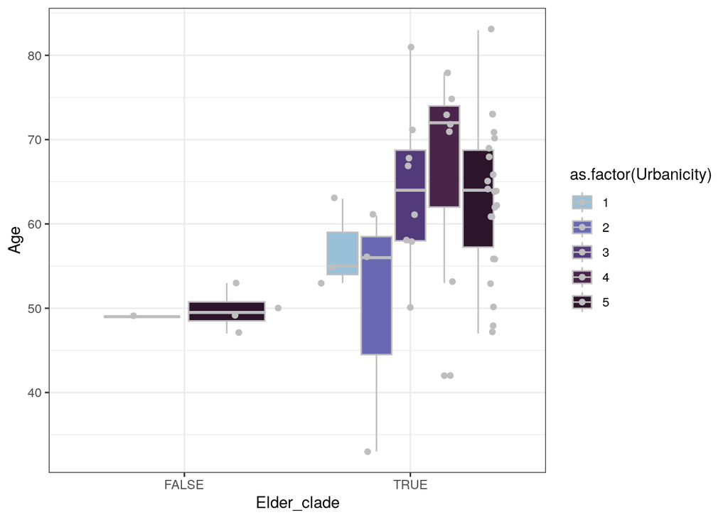

```r
Test_urbanicty %>% ggplot(aes(x=Elder_clade, y=Age, fill=as.factor(Urbanicity)  )) + geom_boxplot(color='grey') + ggforce::geom_sina(color='grey') + theme_bw() + scale_fill_manual( values=c('#98C1D9', '#6969B3', '#533A7B', '#4B244A', '#2C142B' ) )
```

## Functional analyses

### Gene enrichment test

```r
#Gene info R. gnavus
read_tsv("/mnt/project/Make_Associations/Functional_enrichment/MAG_analysis/Gene_presence/t__SGB4584.tsv") -> UniRef90_gnavus
UniRef90_gnavus_wide <- UniRef90_gnavus %>% select(Sample, Gene) %>% filter(Sample %in% Combined_info$sample_id) %>% mutate(N = 1) %>% distinct() %>% spread(Gene, N)
UniRef90_gnavus_wide[is.na(UniRef90_gnavus_wide)] =  0

Info_genomes = UniRef90_gnavus %>% select(Sample , Completeness, Contamination) %>% distinct()
Info_genomes_xu= read_tsv("/mnt/project/Make_Associations/Functional_enrichment/Assemblies/XuQ_Rgnavus_checkm.tsv")
colnames(Info_genomes_xu) = colnames(Info_genomes)
rbind(Info_genomes, Info_genomes_xu) -> Info_genomes
```

Run gene enrichment test

```r
GeneEnrichmentTest = function(DF_uniref, UniRef90_wide=UniRef90_gnavus_wide, Test = "logistic", Completedness_cutoff = 0 ){
  DF_uniref %>% filter(Completeness >=  Completedness_cutoff) -> DF_uniref
  DF_uniref %>% group_by(Elder_clade) %>% summarise(n()) %>% print()

  DF_uniref %>% filter(Elder_clade==T) %>% select(colnames(UniRef90_wide%>% select(-Sample)))  %>% apply(2, function(x){ sum(x)/length(x) } ) -> Prevalences_cent

  DF_uniref %>% filter(Elder_clade==F) %>% select(colnames(UniRef90_wide %>% select(-Sample)))  %>% apply(2, function(x){ sum(x)/length(x) } ) -> Prevalences_nocent

  #Test only if difference of prevalence is big enough
  abs(Prevalences_cent - Prevalences_nocent) -> dif_Prevalence_cent
  Genes_test_c = names(dif_Prevalence_cent)[dif_Prevalence_cent>0.3]

  Results_test_c=tibble()
  N = 0

  for (Gene in Genes_test_c ){
    DF_uniref %>% filter(!is.na(!!sym(Gene))) -> Info_with_genes2
    mean(Info_with_genes2[Gene] %>% as_vector() ) -> Prevalence
    mean( filter(Info_with_genes2, Elder_clade==T  )[Gene] %>% as_vector()) -> Prevalence_high
    mean( filter(Info_with_genes2, Elder_clade==F  )[Gene] %>% as_vector()) -> Prevalence_low

    N = N + 1

    if (Test == "Fisher"){
      #Add pseudocount
      Info_with_genes2 %>% group_by(!!sym(Gene), Elder_clade) %>% summarise(N = n()) %>% drop_na() %>% spread(Elder_clade, N) %>% ungroup() %>% as.data.frame() %>% column_to_rownames(Gene) -> Table_test
      if (dim(Table_test)[1] < 2){ next }
      Table_test[is.na(Table_test)] = 0
      Table_test = Table_test + 1 #Add pseudcount

      Test_p = fisher.test(Table_test)
      Fold_Change = Prevalence_high/Prevalence_low
      Results = tibble( Prevalence_rest = Prevalence_low, Prevalence_clade = Prevalence_high, Fold=Fold_Change, P = Test_p$p.value, Odds_ratio = Test_p$estimate, Lower_bound = Test_p$conf.int[1], Upper_bound = Test_p$conf.int[2], Gene = Gene     )
    Results_test_c = rbind(Results_test_c  , Results %>% mutate(Gene=Gene) )
    } else if ( Test == "logistic" ){
      if ( Prevalence_low !=0 & Prevalence_high !=0 ){
        Formula = paste0( Gene, " ~ Elder_clade + Completeness + Contamination" )
        Info_with_genes2 %>% glm(Formula , . , family=binomial()) %>% summary() -> Results
        Res = Results$coefficients %>% as.data.frame() %>% rownames_to_column("Feature")  %>% filter(Feature %in%  c("Elder_cladeTRUE")) %>% as_tibble() %>% mutate(Prevalence_rest = Prevalence_low, Prevalence_clade = Prevalence_high, Gene= Gene  )
        Res %>% rbind(Results_test_c, . ) -> Results_test_c
      } else {
        Res = tibble( Gene = Gene, Prevalence_rest = Prevalence_low, Prevalence_clade = Prevalence_high, Feature="Elder_cladeTRUE",Estimate =NA, `Std. Error`=NA, `z value`=NA, `Pr(>|z|)`=NA  )
        if (dim(Results_test_c)[1] == 0 ){  Results_test_c = Res
        } else { rbind(Results_test_c,  Res) -> Results_test_c }
      }
  }

  }
  return(Results_test_c)
}
```

Do enrichment in Xu

```r
read_tsv("/mnt/project/Make_Associations/Functional_enrichment/MAG_analysis/Analysis_nonagenarianClade/Presence_gene_long.tsv") -> UniRef90_xu
UniRef90_wide_xu <- UniRef90_xu %>% select(ID_anal, Gene) %>% filter(ID_anal %in% Age_xu2$sample_id) %>%
  mutate(N = 1) %>% distinct() %>% spread(Gene, N)
UniRef90_wide_xu[is.na(UniRef90_wide_xu)] =  0


Age_xu2  %>% filter(sample_id %in% UniRef90_xu$ID_anal)  %>% left_join(., UniRef90_wide_xu %>% rename(sample_id = ID_anal), by="sample_id" ) %>% distinct(sample_id, .keep_all = T) %>%  left_join( Info_genomes%>% distinct() %>%  rename(sample_id = Sample) ) -> XuUniRef
XuUniRef %>% group_by(Elder_clade) %>% summarise(n()) %>% print()
```

```
## # A tibble: 2 × 2
##   Elder_clade `n()`
##   <fct>       <int>
## 1 FALSE          19
## 2 TRUE            9
```

```r
Results_test_xu = GeneEnrichmentTest( DF_uniref =  XuUniRef,UniRef90_wide = UniRef90_wide_xu %>% rename(Sample = ID_anal), Test = "Fisher",  Completedness_cutoff = 90)
```

```
## # A tibble: 2 × 2
##   Elder_clade `n()`
##   <fct>       <int>
## 1 FALSE          15
## 2 TRUE            9
```

```r
write_tsv(Results_test_xu, "Supp_Tables_update/XuQ_Rgnavus_GeneEnrichment_elderClade_highQMAGs.tsv")
```

Check in European samples

```r
Age_europe2 %>% filter(sample_id %in% UniRef90_gnavus_wide$Sample) %>% filter(Continent == "Europe") %>% left_join(., UniRef90_gnavus_wide %>% rename(sample_id = Sample), by="sample_id" ) %>% distinct(sample_id, .keep_all = T) %>%  left_join( Info_genomes%>% distinct() %>%  rename(sample_id = Sample) ) -> EuropeanUniRef
EuropeanUniRef %>% group_by(Elder_clade) %>% summarise(n()) %>% print()
```

```
## # A tibble: 2 × 2
##   Elder_clade `n()`
##   <fct>       <int>
## 1 FALSE          43
## 2 TRUE           24
```

```r
Results_test_c = GeneEnrichmentTest( DF_uniref =  EuropeanUniRef,UniRef90_wide = UniRef90_gnavus_wide, Test = "Fisher",  Completedness_cutoff = 90 )
```

```
## # A tibble: 2 × 2
##   Elder_clade `n()`
##   <fct>       <int>
## 1 FALSE          11
## 2 TRUE           10
```

```r
write_tsv(Results_test_c, "Supp_Tables_update/Europe_Rgnavus_GeneEnrichment_elderClade_highQMAGs.tsv")
```

Replication between XuQ and European associations

```r
Results_test_xu %>% mutate(FDR = p.adjust(P, "fdr"), Cohorts = "XuQ_2021"  ) -> Results_test_xu
Results_test_c %>% mutate(FDR = p.adjust(P, "fdr"), Cohorts = "European" ) -> Results_test_c
rbind(Results_test_xu, Results_test_c) %>% write_tsv( "Supp_Tables_update/Rgnavus_GeneEnrichment_elderClade_highQMAGs.tsv")



Results_test_xu %>%  group_by(FDR<0.05) %>% summarise(n())
```

```
## # A tibble: 2 × 2
##   `FDR < 0.05` `n()`
##   <lgl>        <int>
## 1 FALSE          448
## 2 TRUE           426
```

```r
Results_test_c %>% filter(FDR<0.05) %>% group_by(Gene %in%  filter(Results_test_xu, FDR<0.05)$Gene ) %>% summarise(n())
```

```
## # A tibble: 2 × 2
##   `Gene %in% filter(Results_test_xu, FDR < 0.05)$Gene` `n()`
##   <lgl>                                                <int>
## 1 FALSE                                                   48
## 2 TRUE                                                   139
```

### MetaCyc Pathways

```r
#Metacyc Pathways : reactions
Enrichment_tables = read_rds("/mnt/project/Make_Associations/Functional_enrichment/MAG_analysis/For_enrichment/metacyc_pathways.rds")
#ECs : reactions
Translate_EC_to_reaction = read_tsv("/mnt/project/Make_Associations/Functional_enrichment/MAG_analysis//For_enrichment/EC_to_reaction.tsv.gz")
```

```r
#Uniref90 to ECs
read_rds("/mnt/project/Make_Associations/Functional_enrichment/MAG_analysis/For_enrichment/UniRef90/ec.rds") -> ECs
ECs_tibble <- enframe(ECs, name = "EC", value = "UniRef90")
ECs_tibble %>% separate_rows(UniRef90, sep="\t")  -> ECs_tibble


Run_enrichment = function(Summary_stats, Table,Plot=F){
  if ("z value" %in% colnames(Summary_stats) ){
    Summary_stats %>%  arrange(desc(`z value`))-> R1
    ranks = R1$`z value`
  } else {
    Summary_stats %>%  arrange(desc(log10(Odds_ratio)))-> R1
    ranks = R1$Fold
  }
  #Prepare ranks

  names(ranks) = as.character(R1$Gene)
  #Run GSEA
  fgseaRes <- fgsea::fgsea(Table, ranks, scoreType = "pos")

  if (Plot == T){
    topPathwaysUp <- fgseaRes[ES > 0][head(order(pval), n=10), pathway]
    topPathwaysDown <- fgseaRes[ES < 0][head(order(pval), n=10), pathway]
    topPathways <- c(topPathwaysUp, rev(topPathwaysDown))
    fgsea::plotGseaTable(Table[topPathways], ranks, fgseaRes,  gseaParam=0.5)
  }

  return(fgseaRes)
}

DoMetaCycEnrichment = function( SummaryStats ){
  if ("Pr(>|z|)" %in% colnames(SummaryStats) ){ SummaryStats %>% rename( P = `Pr(>|z|)` ) }
  #Uniref90 --> EC ---> Reactions --> Metacyc Enrichment
  SummaryStats   %>% mutate(P , "fdr")  %>% rename(UniRef90 = Gene) %>% left_join(ECs_tibble) %>% rename(ec = EC) %>% left_join(Translate_EC_to_reaction) %>%  drop_na()  -> Input2

  MetaCyc_enrichment = Run_enrichment(Input2 %>% rename(Gene = Reaction) ,  Table=Enrichment_tables )
  return(MetaCyc_enrichment)

}
```

Check pathway completeness

```r
TestPathwayCompletion = function(DF_uniref,Results_test, Enrichment_tables, Translate_EC_to_reaction,Completion_MAG=0){
  DF_uniref %>% filter(Completeness >= Completion_MAG) -> DF_uniref

  read_rds("/mnt/project/Make_Associations/Functional_enrichment/MAG_analysis/For_enrichment/UniRef90/ec.rds") -> ECs
  ECs_tibble <- enframe(ECs, name = "EC", value = "UniRef90")
  ECs_tibble %>% separate_rows(UniRef90, sep="\t") -> ECs_tibble

  #Give EC to each pathway
  Results_test %>% left_join(ECs_tibble %>% rename(Gene = UniRef90), relationship = "many-to-many" ) -> merged_ec
  merged_ec %>% drop_na() %>% group_by(Gene) %>% summarise(n())
  #Giving pathway(s) to each EC
  merged_ec %>% left_join(Translate_EC_to_reaction %>% rename(EC = ec)) %>% distinct() -> Merged_info
  #Getting the number of steps per pathway
  Enrichment_tables %>% stack() %>% as_tibble() %>% rename(Reaction =values , Pathways = ind  ) -> Pathwyas_tibble
  Pathwyas_tibble %>% group_by(Pathways) %>% summarise(N = n()) -> Pathways_numbers

  Results_test_pathway=tibble()
  Completedness_total = tibble(sample_id =DF_uniref$sample_id)

  for (Path in unique(Merged_info$Pathways) ){
    print(Path)
    if (! Path %in% Pathways_numbers$Pathways ){ next }
    if(is.na(Path)){ next }
    #Per pathway, get all ECs neccessary for completion
    Translate_EC_to_reaction %>% filter(Pathways == Path) -> ECs_to_check
    #Get the total number of steps
    Denominator =  filter(Pathways_numbers, Pathways == Path)$N
    ECs_tibble %>% filter(EC %in% ECs_to_check$ec) -> ECs_to_check

    #Get pathway members
    DF_uniref  %>% select( c(sample_id, any_of(ECs_to_check$UniRef90 ) ) ) -> N_pathway

    N_pathway %>% gather(UniRef90, value ,colnames(select(N_pathway, -sample_id)) )  %>% left_join(ECs_to_check) %>% group_by(sample_id, EC) %>% summarise(C = sum(value)) %>% mutate(Numerator = ifelse(C > 1 , 1, C ) ) %>% group_by(sample_id) %>% summarise(N = sum(Numerator)) %>%
    mutate(Fraction_complete = N/Denominator  ) %>% left_join( select(DF_uniref, c(sample_id,  Elder_clade) ) ) -> For_test

  wilcox.test( filter(For_test, Elder_clade == T)$Fraction_complete, filter(For_test, Elder_clade == F)$Fraction_complete, exact = F) -> Result

  For_test %>% group_by(Elder_clade) %>% summarise(Median_completion = median(Fraction_complete) ) -> Result_info

  tibble(Pathway = Path, P=Result$p.value, Median_completion_clade = filter(Result_info,Elder_clade == T)$Median_completion,Median_completion_noclade = filter(Result_info,Elder_clade == F)$Median_completion   ) %>% rbind(Results_test_pathway, .) -> Results_test_pathway

  #Get completedness df
  For_test %>% select(sample_id, Fraction_complete) -> To_save
  colnames(To_save)[2] = Path
  left_join(Completedness_total, To_save, by="sample_id") %>% as_tibble() -> Completedness_total
}


  Results_test_pathway %>% arrange(P) %>% mutate( FDR = p.adjust(P, "fdr") ) -> Results_test_pathway
  return(list( 'Results' = Results_test_pathway, 'DF_completedness' =  Completedness_total) )
}
```

```r
Completedness_Xu =  TestPathwayCompletion(XuUniRef ,Results_test_xu, Enrichment_tables, Translate_EC_to_reaction, Completion_MAG=90 )
```

[output not shown]

```
## [1] "LACTOSEUTIL-PWY"
```

```
## [1] "PWY-6518"
```

```
## [1] "PWY-7091"
```

```
## [1] "PWY-7092"
```

```
## [1] "PWY-6002,PWY-7092"
## [1] "PWY-6788"
```

```
## [1] "PWY-3121,PWY-7091"
## [1] "PWY-5176"
```

[output not shown]

[output not shown]

[output not shown]

```
## [1] "PWY-6527"
```

```
## [1] "PWY0-1301"
```

```
## [1] "PHOSPHONOTASE-PWY,PWY-6832"
## [1] "PHOSPHONOTASE-PWY"
```

```
## [1] "ARO-PWY,PWY-6416,PWY-6630,PWY-6629,PWY-6628,PWY-6954,PWY-2504,PWY-6707,COMPLETE-ARO-PWY,QUINATEDEG-PWY,ALL-CHORISMATE-PWY,PWY-6165,PWY-6163"
## [1] "PWY-6938"
```

```
## [1] "ALANINE-VALINESYN-PWY,PWY-7389,PWY-7383,PWY0-1061,ALADEG-PWY"
## [1] "PWY-842"
```

```
## [1] "PWY0-1309"
```

[output not shown]

```
## [1] "RIBOKIN-PWY"
```

```
## [1] "PWY-5384"
```

```
## [1] "PANTOSYN-PWY,PWY-5155"
## [1] "PWY-4221,PWY-6654,PANTO-PWY,PANTOSYN-PWY"
## [1] "TRNA-CHARGING-PWY"
```

```
## [1] "PWY-5067"
```

```
## [1] "GLYCOGENSYNTH-PWY"
```

```
## [1] "PWY-622"
```

```
## [1] "PWY-6415,PWY-4821,PWY-7328,PWY3DJ-35471,COLANSYN-PWY,PWY-5114,PWY-7346"
```

```r
Completedness_Eur =  TestPathwayCompletion(EuropeanUniRef ,Results_test_c, Enrichment_tables, Translate_EC_to_reaction, Completion_MAG=90 )
```

[output not shown]

```
## [1] "LACTOSEUTIL-PWY"
```

[output not shown]

[output not shown]

[output not shown]

```
## [1] "PWY-6470"
```

```
## [1] "PWY-6710"
```

[output not shown]

[output not shown]

```
## [1] "PHOSPHONOTASE-PWY,PWY-6832"
## [1] "PHOSPHONOTASE-PWY"
```

```
## [1] "ARO-PWY,PWY-6416,PWY-6630,PWY-6629,PWY-6628,PWY-6954,PWY-2504,PWY-6707,COMPLETE-ARO-PWY,QUINATEDEG-PWY,ALL-CHORISMATE-PWY,PWY-6165,PWY-6163"
## [1] "PWY-6938"
```

```
## [1] "ALANINE-VALINESYN-PWY,PWY-7389,PWY-7383,PWY0-1061,ALADEG-PWY"
## [1] "PWY-842"
```

```
## [1] "PWY0-1309"
```

[output not shown]

```
## [1] "PWY-7376,P381-PWY"
## [1] "PWY-6527"
```

```
## [1] "PWY0-1301"
```

```
## [1] "PWY0-1280,GLYCOL-GLYOXDEG-PWY"
## [1] "PWY0-1315,FUC-RHAMCAT-PWY"
## [1] "MGLDLCTANA-PWY"
```

```
## [1] "PWY-5384"
```

```
## [1] "PANTOSYN-PWY,PWY-5155"
## [1] "PWY-4221,PANTO-PWY,PANTOSYN-PWY"
## [1] "PWY-4221,PWY-6654,PANTO-PWY,PANTOSYN-PWY"
```

```r
rbind(Completedness_Xu[['Results']] %>% mutate(Cohorts = "XuQ_2021")  , Completedness_Eur[['Results']] %>% mutate(Cohorts = "European") ) %>% write_tsv( "Supp_Tables_update/Rgnavus_PathCompletion_elderClade_highQMAGs.tsv")

#write_tsv(Completedness_Xu$Results, "Supp_Tables_update/XuQ_Rgnavus_PathCompletion_elderClade_highQMAGs.tsv")
#write_tsv(Completedness_Eur$Results, "Supp_Tables_update/Europe_Rgnavus_PathCompletion_elderClade_highQMAGs.tsv")
```

### Biosynthetic gene clusters

```r
BGCTest = function(Info_with_gutsmash, Test = "logistic", Completedness_cutoff = 90 ){
 Info_with_gutsmash %>% filter(Completeness >=  Completedness_cutoff) -> Info_with_gutsmash
 Info_with_gutsmash %>% group_by(Elder_clade) %>% summarise(n()) %>% print()


 Results_gutsmash = tibble()
  for (Module in colnames(GS_qin %>% select(-sample_id))){
    Info_with_gutsmash %>% filter(!is.na(!!sym(Module))) -> Info_with_genes2
    mean(Info_with_genes2[Module] %>% as_vector() ) -> Prevalence
    mean( filter(Info_with_genes2, Elder_clade==T  )[Module] %>% as_vector()) -> Prevalence_high
    mean( filter(Info_with_genes2, Elder_clade==F  )[Module] %>% as_vector()) -> Prevalence_low

    if ( Test == "Fisher"){
      Info_with_genes2 %>% group_by(!!sym(Module), Elder_clade) %>% summarise(N = n()) %>% drop_na() %>% spread(Elder_clade, N) %>% ungroup() %>% as.data.frame() %>% column_to_rownames(Module) -> Table_test
      if (dim(Table_test)[1] < 2){ next }
      Table_test[is.na(Table_test)] = 0
      Table_test = Table_test + 1 #Add pseudcount

      Test_p = fisher.test(Table_test)
      Prevalence = apply(Table_test, 2, function(x){ x[2]/sum(x)  }  )
      Fold_Change = as.vector(Prevalence[1])/as.vector(Prevalence[2])
      Results = tibble( Prevalence_rest = Prevalence[1], Prevalence_clade = Prevalence[2], Fold=Fold_Change, P = Test_p$p.value, Odds_ratio = Test_p$estimate, Lower_bound = Test_p$conf.int[1], Upper_bound = Test_p$conf.int[2]    )
      Results_gutsmash = rbind(Results_gutsmash  , Results %>% mutate(BGC=Module) )
    } else if ( Test == "logistic" ){
      if ( Prevalence_low !=0 & Prevalence_high !=0 ){
        Formula = paste0("`", Module, "` ~ Elder_clade + Completeness + Contamination" )
        Info_with_gutsmash %>% glm(Formula , . , family=binomial()) %>% summary() -> Results
        Res = Results$coefficients %>% as.data.frame() %>% rownames_to_column("Feature")  %>% filter(Feature %in%  c("Elder_cladeTRUE")) %>% as_tibble() %>% mutate(Prevalence_rest = Prevalence_low, Prevalence_clade = Prevalence_high, BGC= Module  )
        Res %>% rbind(Results_gutsmash, . ) -> Results_gutsmash
      } else {
        Res = tibble( BGC = Module, Prevalence_rest = Prevalence_low, Prevalence_clade = Prevalence_high, Feature="Elder_cladeTRUE",Estimate =NA, `Std. Error`=NA, `z value`=NA, `Pr(>|z|)`=NA  )
        if (dim(Results_gutsmash)[1] == 0 ){  Results_gutsmash = Res
        } else { rbind(Results_gutsmash,  Res) -> Results_gutsmash }
      }

    }
  }

  return(Results_gutsmash)
}
```

```r
#gutSmash
GS_qin = read_tsv("/mnt/project/Make_Associations/Functional_enrichment/MAG_analysis/GutSmash/GutSmash_QinN_2021.tsv", col_names=F)
GS_qin %>% rename(sample_id = X1) %>% select(-X2) %>% distinct() %>% mutate(Presence=1) %>% spread(X3, Presence) -> GS_qin
GS_qin[is.na(GS_qin)] = 0
GS_qin %>% select(-sample_id) %>% apply(2, function(x){ sum(x)/length(x) } )
```

```
## BGC type: Flavoenzyme_AA_peptides_catabolism
##                                   0.85714286
##       BGC type: Flavoenzyme_sugar_catabolism
##                                   0.57142857
##                 BGC type: Fumarate2succinate
##                                   0.03571429
##                 BGC type: GR_eut-pdu-related
##                                   0.75000000
##              BGC type: Others_HGD_unassigned
##                                   0.96428571
##                 BGC type: Oxidative_glycerol
##                                   0.10714286
##                    BGC type: PFOR_II_pathway
##                                   0.96428571
##              BGC type: Putrescine2spermidine
##                                   0.96428571
##           BGC type: Pyruvate2acetate-formate
##                                   0.82142857
##                        BGC type: Rnf_complex
##                                   0.82142857
##               BGC type: succinate2propionate
##                                   0.75000000
##                  BGC type: TPP_AA_metabolism
##                                   0.75000000
```

```r
left_join(Age_xu2, GS_qin) %>% drop_na() -> Info_with_gutsmash
left_join(Info_with_gutsmash, Info_genomes, by=c("sample_id" = "Sample") ) -> Info_with_gutsmash

Results_gutsmash = BGCTest(Info_with_gutsmash, Test = "Fisher", Completedness_cutoff = 90)
```

```
## # A tibble: 2 × 2
##   Elder_clade `n()`
##   <fct>       <int>
## 1 FALSE          15
## 2 TRUE            9
```

```r
Results_gutsmash %>% as_tibble() %>% arrange(P) %>% mutate(FDR= p.adjust(P, "fdr") ) -> Results_gutsmash
write_tsv(Results_gutsmash, "Supp_Tables_update/XuQ_Rgnavus_BGC_elderClade_highQMAGs.tsv")
```

Replicate in rest of non-Xu samples

```r
GS_no_qin = read_tsv("/mnt/project/Make_Associations/Functional_enrichment/MAG_analysis/GutSmash/GutSmash_noQinN_2021.tsv", col_names=F)
GS_no_qin %>% rename(sample_id = X1) %>% select(-X2) %>% distinct() %>% mutate(Presence=1) %>% spread(X3, Presence) -> GS_no_qin
GS_no_qin[is.na(GS_no_qin)] = 0
left_join(Age_europe2, GS_no_qin  ) %>% drop_na() -> Info_with_gutsmash2
left_join(Info_with_gutsmash2, Info_genomes, by=c("sample_id" = "Sample") ) -> Info_with_gutsmash2
Info_with_gutsmash2 %>% group_by(Elder_clade) %>% summarise(n())
```

```
## # A tibble: 2 × 2
##   Elder_clade `n()`
##   <fct>       <int>
## 1 FALSE          49
## 2 TRUE           28
```

```r
Info_with_gutsmash2 %>% filter(Completeness >= 90) %>% group_by(`BGC type: Flavoenzyme_sugar_catabolism`, Elder_clade) %>% summarise(N = n()) %>% ungroup() %>%  drop_na() %>% spread(Elder_clade, N)  %>% as.data.frame() %>% column_to_rownames("BGC type: Flavoenzyme_sugar_catabolism") -> Table_test
```

[output not shown]

```r
Table_test[is.na(Table_test)] = 0 #; Table_test = Table_test + 1
Test_p = fisher.test(Table_test)
print(Test_p$p.value) ; print(Test_p$estimate)
```

```
## [1] 0.004576659
```

```
## odds ratio
##          0
```

Run with all samples at once

```r
Results_gutsmash_all = BGCTest(full_join(Info_with_gutsmash,Info_with_gutsmash2), Test = "Fisher", Completedness_cutoff = 90)
```

[output not shown]

```
## # A tibble: 2 × 2
##   Elder_clade `n()`
##   <fct>       <int>
## 1 FALSE          26
## 2 TRUE           21
```

```r
Results_gutsmash_all %>% arrange(P) %>% mutate(FDR = p.adjust( P, 'fdr') ) -> Results_gutsmash_all
write_tsv(Results_gutsmash_all, "Supp_Tables_update/Rgnavus_BGC_elderClade_highQMAGs_all.tsv")
```

### Roary pangenome

```r
Prepare_roary = function(Tree_gnavus_all){
  read_csv("/mnt/project/Make_Associations/Functional_enrichment/MAG_analysis/Analysis_nonagenarianClade/Roary_scripts/rgnavus_roary_1728930398/gene_presence_absence.csv")-> GeneContent
  Columns_k = colnames(GeneContent)[15:length(colnames(GeneContent))]
  GeneContent %>% select(c("Gene", Columns_k ) ) -> GeneContent2
  GeneContent2 %>% as.data.frame() %>% column_to_rownames("Gene") %>% mutate_all(~ ifelse(is.na(.), 0, 1)) %>%  rownames_to_column("Gene") %>% as_tibble() -> GeneContent2
  GeneContent2 %>% column_to_rownames("Gene") %>% t() %>% as_tibble() %>% mutate(MAG_ID = colnames(GeneContent2 %>% select(-Gene)), .before=1 ) -> GeneContent2

  GeneContent2$MAG_ID %>% sapply( function(x){ if(grepl("bin", x)){ str_split(x, ".bin")[[1]][1] %>% return() }else{ return(x) }   }  ) -> IDs
  GeneContent2 = GeneContent2 %>% mutate(ID_anal = IDs, .before=1) %>%
   filter(ID_anal %in% Tree_gnavus_all$tip.label )
}
Select_genes = function(Combined_info2, GeneContent2){
  Combined_info2 %>% left_join(GeneContent2, by=c("sample_id"="ID_anal") ) %>% select(Elder_clade, colnames(GeneContent2 %>% select(-ID_anal) ) ) %>% filter(! is.na( MAG_ID)  ) -> Genes_elder

  Genes_elder %>% group_by(Elder_clade) %>% summarise(n())

  Keep_genes = c()
  for ( Gene_family in colnames(Genes_elder) ){
    if ( Gene_family %in% c("Elder_clade", "MAG_ID" ) ) { next }
    Prevalence_elder = mean(Genes_elder[Genes_elder$Elder_clade == T,][[Gene_family]])
    #Prevalence_rest = mean(Genes_elder[Genes_elder$Elder_clade == F,][[Gene_family]])
    if ( Prevalence_elder >= 0.9  ){ Keep_genes = c(Keep_genes, Gene_family) }
  }
  return(Keep_genes)
}
```

Replication of tree using MAG-based phylogenetic tree reconstructed with roary

```r
read.tree("/mnt/project/Make_Associations/Functional_enrichment/MAG_analysis/Analysis_nonagenarianClade/Roary_scripts/rgnavus_roary_1728930398/accessory_binary_genes.fa.newick") -> Roary_phylogeny

Roary_phylogeny$tip.label %>% sapply( function(x){ if(grepl("bin", x)){ str_split(x, ".bin")[[1]][1] %>% return() }else{ return(x) }   }  ) -> Roary_phylogeny$tip.label

keep.tip(Roary_phylogeny, Tree_gnavus_all$tip.label[Tree_gnavus_all$tip.label %in% Roary_phylogeny$tip.label] ) -> Roary_phylogeny

keep.tip(Roary_phylogeny, Combined_info2$sample_id[ Combined_info2$sample_id %in% Roary_phylogeny$tip.label] ) -> Roary_phylogeny


ggtree(Roary_phylogeny, layout="fan", open.angle=15, size=0.1) %<+% Combined_info2  -> p
```

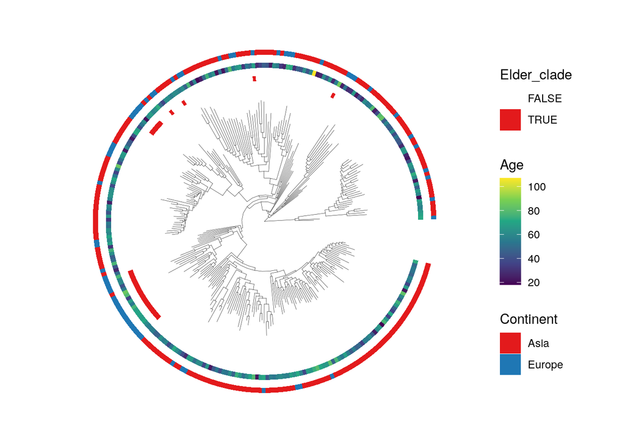

```r
  p + geom_fruit( geom="geom_tile", mapping = aes(fill=Elder_clade), width=0.03,offset=0.1) + scale_fill_manual(values=c("TRUE"= "#E31A1C", "FALSE"="white") )  +
  new_scale_fill() + geom_fruit( geom="geom_tile", mapping = aes(fill=Age), width=0.03,offset=0.1 )  + scale_fill_viridis_c(option = "viridis") + new_scale_fill() + geom_fruit( geom="geom_tile", mapping = aes(fill=Continent), width=0.03,offset=0.1 ) + scale_fill_manual(values=c("Europe" = "#1f77b4", "Asia" = "#E31A1C"))
```

### Bile acid genes

```r
read_csv('/mnt/project/Make_Associations/Functional_enrichment/MAG_analysis/Analysis_nonagenarianClade/BA_genes/HMMs/hmm_results_summary.csv', col_names = T) %>% rename( Gene=`...1` ) -> BA_genes
```

[output not shown]

```r
BA_genes[is.na(BA_genes)] = 0

BA_genes %>% as.data.frame() %>% column_to_rownames('Gene') %>% t() %>% as.data.frame() %>% rownames_to_column('sample_id') %>% as_tibble() ->  BA_genes

BA_genes$sample_id %>% sapply(function(x){
            if ( grepl('bin', x ) ) {
                if (grepl("__bin", x) ){
                        str_split(x, "__")[[1]][1]  %>% return()
                } else { str_split(x, "_bin")[[1]][1] %>% return() }
            } else { return(x) }    } )     -> BA_genes$sample_id



BA_genes %>% distinct(sample_id, .keep_all = T) %>% filter(sample_id %in%  Combined_info2$sample_id ) -> BA_genes

BA_genes %>% select(-sample_id) %>% vegan::vegdist(method = 'jaccard') -> Dist_ba
pcoa(Dist_ba) -> PCoA

BA_genes_binary_filtered <- BA_genes %>% select(-sample_id) %>%
     select_if(~ var(.) > 0)
phi_correlation_matrix <- cor(BA_genes_binary_filtered, method = "pearson")


BA_genes_merged = left_join(BA_genes,Combined_info2 %>% distinct(sample_id, .keep_all = T) ) %>% filter(!is.na(Elder_clade))
```

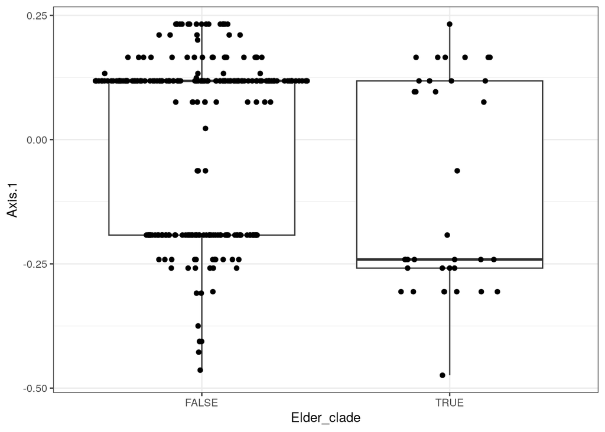

```r
PCoA$vectors %>% as_tibble() %>% cbind(BA_genes_merged) %>% ggplot(aes(y=`Axis.1`, x=Elder_clade ))  + theme_bw() + geom_boxplot(outlier.shape = NA) + ggforce::geom_sina()
```

```r
left_join(BA_genes_merged, Info_genomes, by=c("sample_id"="Sample")) %>% filter(Completeness > 0.9) ->BA_genes_merged
BA_genes_merged %>% group_by(Elder_clade) %>% summarise(n())
```

```
## # A tibble: 2 × 2
##   Elder_clade `n()`
##   <fct>       <int>
## 1 FALSE         272
## 2 TRUE           36
```

```r
BA_res =tibble()
for (Gene in colnames(BA_genes_merged) ){
  if (Gene %in%  c(colnames(Combined_info2), colnames(Info_genomes)  ) ){ next }
  BA_genes_merged %>% group_by(Elder_clade, !!sym(Gene) ) %>% summarise(N = n()) %>% ungroup() -> N_perc

  Mean_clade = filter(BA_genes_merged, Elder_clade==T)[[Gene]] %>% mean()
  Mean_noclade = filter(BA_genes_merged, Elder_clade==F)[[Gene]] %>% mean()


  paste0( "`", Gene,"`", "~ Elder_clade"  ) -> Formula
  glm(Formula, BA_genes_merged, family='binomial') %>% summary() -> Res
  Res$coefficients %>% as.data.frame() %>% rownames_to_column('Feature') %>% filter(Feature == "Elder_cladeTRUE" ) %>% as_tibble() %>% mutate(Gene = Gene, Clade_prevalence=Mean_clade, noClade_prevalence=Mean_noclade ) -> Res
  rbind(BA_res, Res) -> BA_res

}
BA_res %>% arrange( `Pr(>|z|)`) %>% mutate(FDR = p.adjust(`Pr(>|z|)`, "fdr") ) ->  BA_res
write_tsv(BA_res, "Supp_Tables_update/Rgnavus_BileAcids_elderClade_highQMAGs_all.tsv" )

BA_res %>% select(-c(Feature, `Std. Error`, `z value`))
```

```
## # A tibble: 13 × 6
##     Estimate    `Pr(>|z|)` Gene    Clade_prevalence noClade_prevalence       FDR
##        <dbl>         <dbl> <chr>              <dbl>              <dbl>     <dbl>
##  1 -2.37e+ 0 0.00000000362 7βHSDH             0.278            0.805     3.30e-8
##  2  2.42e+ 0 0.00000000508 BSH                0.444            0.0662    3.30e-8
##  3  1.02e+ 0 0.00463       BaiA               0.583            0.335     2.01e-2
##  4  9.61e- 1 0.00754       3αHSDH             0.556            0.324     2.45e-2
##  5  4.03e- 1 0.597         7αHSDH             0.944            0.919     1   e+0
##  6  5.88e- 2 0.956         3βHSDH             0.972            0.971     1   e+0
##  7 -1.60e+ 1 0.997         12αHSDH            0                0.00368   1   e+0
##  8 -6.16e-16 1             BaiB               0                0         1   e+0
##  9 -5.94e-16 1             BaiCD              1                1         1   e+0
## 10 -6.16e-16 1             BaiF               0                0         1   e+0
## 11 -6.16e-16 1             BaiG               0                0         1   e+0
## 12 -5.94e-16 1             BaiH               1                1         1   e+0
## 13 -6.16e-16 1             BaiE               0                0         1   e+0
```